# HW3 Gene Expression

### Q8) Sort the empirical Bayes p-values and acquire the lowest n p-values, where n is defined as the number of significant test statistics that you found in problem 6. Intersect the gene names for your two methods and report how many are in common between the two differential expression methods, when choosing the top n genes from each set. (2.5 pts)

```r
### Q8) Compare top-n genes between Wilcoxon and limma eBayes (robust alignment) ----

# Requirements
stopifnot(exists("sig_df"), exists("original.wmw.run"), exists("limma_df"))

# 1) Align gene universes (avoid name/order mismatches)
wmw_genes   <- names(original.wmw.run)
limma_genes <- limma_df$Gene
common_genes <- intersect(wmw_genes, limma_genes)

cat("Gene universe:\n",
    "  WMW genes:", length(wmw_genes), "\n",
    "  limma genes:", length(limma_genes), "\n",
    "  common genes:", length(common_genes), "\n")
```

```
Gene universe:
   WMW genes: 7130
   limma genes: 7130
   common genes: 7130
```

```r
# Filter all objects to the common set
# (a) original.wmw.run
original.wmw.run <- original.wmw.run[common_genes]

# (b) sig_df (Wilcoxon-selected genes from Q6)
sig_df <- sig_df[sig_df$Gene %in% common_genes, , drop = FALSE]

# (c) limma_df
limma_df <- limma_df[limma_df$Gene %in% common_genes, , drop = FALSE]

# 2) n = number of WMW-significant genes AFTER alignment
n <- nrow(sig_df)
cat("Number of WMW-significant genes after alignment (n):", n, "\n")
```

```
Number of WMW-significant genes after alignment (n): 22
```

```r
if (n > 0) {
  # 3) Get top-n by each method on the aligned universe
  # limma: smallest p-values
  top_limma <- head(limma_df$Gene[order(limma_df$p_value)], n)
  # WMW: largest Wilcoxon W
  top_wmw   <- head(sig_df$Gene[order(-sig_df$W_Statistic)], n)

  # 4) Overlap
  overlap <- intersect(top_wmw, top_limma)
  overlap_count <- length(overlap)
  cat("Overlap between top", n, "genes (WMW vs limma):", overlap_count, "\n")

  # 5) Optional table with ranks + stats for the overlapping genes
  if (overlap_count > 0) {
    # ranks within each method
    wmw_rank   <- rank(-original.wmw.run, ties.method = "min")[overlap]
    limma_rank <- rank(limma_df$p_value, ties.method = "min")[match(overlap, limma_df$Gene)]

    overlap_df <- data.frame(
      Gene        = overlap,
      WMW_W       = original.wmw.run[overlap],
      WMW_Rank    = wmw_rank,
      Limma_p     = limma_df$p_value[match(overlap, limma_df$Gene)],
      Limma_Rank  = limma_rank,
      row.names   = NULL
    )
    overlap_df <- overlap_df[order(overlap_df$WMW_Rank), ]

    datatable(
      overlap_df,
      options = list(pageLength = 10, scrollX = TRUE),
      caption = sprintf("Overlap of top %d genes between WMW and limma (count = %d)", n, overlap_count)
    )
  } else {
    cat("No overlapping genes among the top-n sets.\n")
  }
} else {
  cat("No WMW-significant genes after alignment; cannot compute overlap.\n")
}
```

```
Overlap between top 22 genes (WMW vs limma): 0
No overlapping genes among the top-n sets.
```

### Q9) Finally, compare the results from a Student’s t-test with the empirical Bayes method. To do this, first calculate a two sample (two-tailed) Student’s t-test on all genes. Make sure that you are running a Student’s t-test and not a Welch’s t-test. Then extract only those genes with a p-value less than 0.01 from this test. Plot the gene p-values<0.01 for the Student’s t-test vs. the same genes in the empirical Bayes method. Make sure to label the axes and title appropriately. (7.5 pts)

```r
### Q9) Compare Student's t-test with empirical Bayes (limma) ----

# Sanity: confirm data exists
stopifnot(exists("golub_df_with_labels"), exists("limma_df"))

# Prepare class indices
idx_ALL <- which(golub_df_with_labels$Class == "ALL")
idx_AML <- which(golub_df_with_labels$Class == "AML")

# Perform Student's (equal-variance) t-test for each gene
student_t_pvals <- apply(golub_df_with_labels[, -1, drop = FALSE], 2, function(x) {
  t.test(x[idx_ALL], x[idx_AML], var.equal = TRUE)$p.value
})

# Number of genes passing p < 0.01
sig_t_idx <- which(student_t_pvals < 0.01)
cat("Genes with Student's t-test p < 0.01:", length(sig_t_idx), "\n")
```

```
Genes with Student's t-test p < 0.01: 800
```

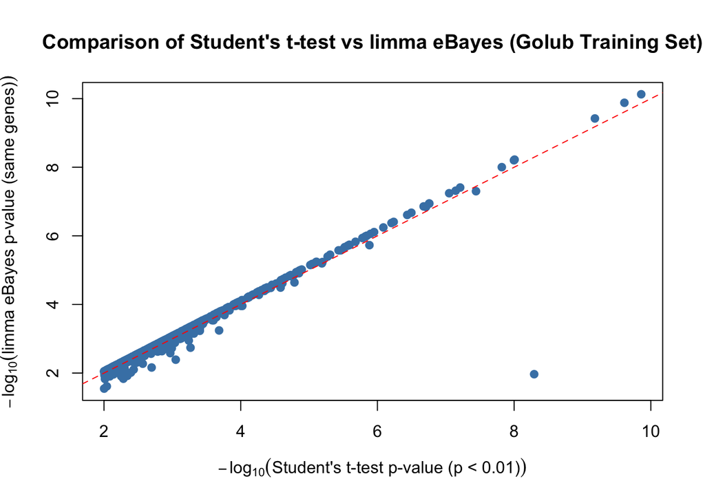

|  | Gene | Student_t_p | Limma_p |
| --- | --- | --- | --- |
| g3321 | g3321 | 1.382385657332042e-10 | 7.446662759633062e-11 |
| g4848 | g4848 | 2.435528473277847e-10 | 1.31788761623769e-10 |
| g2021 | g2021 | 6.577977412771993e-10 | 3.779861009504781e-10 |
| g1 | g1 | 5.090377997318544e-09 | 0.01079839638305398 |
| g1746 | g1746 | 9.846897254435025e-09 | 5.987511855866233e-09 |
| g5040 | g5040 | 1.005968567021927e-08 | 6.259115538783908e-09 |
| g1835 | g1835 | 1.514532216430054e-08 | 9.925633003908057e-09 |
| g462 | g462 | 3.610124227026674e-08 | 4.994555783511227e-08 |
| g4197 | g4197 | 6.156940644228055e-08 | 3.900036400237173e-08 |
| g3848 | g3848 | 7.157106018903862e-08 | 4.823792477418094e-08 |

```r
if (length(sig_t_idx) > 0) {
  # Extract gene names and matching limma p-values
  sig_genes_t <- names(student_t_pvals)[sig_t_idx]
  p_t <- student_t_pvals[sig_genes_t]
  p_limma <- limma_df$p_value[match(sig_genes_t, limma_df$Gene)]

  # Combine into a dataframe for plotting
  compare_df <- data.frame(
    Gene = sig_genes_t,
    Student_t_p = p_t,
    Limma_p = p_limma
  )

  # Scatter plot: raw p-values (both on log10 scale for clarity)
  plot(
    -log10(compare_df$Student_t_p),
    -log10(compare_df$Limma_p),
    pch = 19, col = "steelblue",
    xlab = expression(-log[10](paste("Student's t-test p-value (p < 0.01)"))),
    ylab = expression(-log[10](paste("limma eBayes p-value (same genes)"))),
    main = "Comparison of Student's t-test vs limma eBayes (Golub Training Set)"
  )
  abline(0, 1, lty = 2, col = "red")

  # Optional DT preview of first 10 genes
  datatable(
    head(compare_df[order(compare_df$Student_t_p), ], 10),
    options = list(pageLength = 10, scrollX = TRUE),
    caption = "Top 10 genes (Student's t-test p < 0.01) with corresponding limma p-values"
  )
} else {
  cat("No genes found with Student's t-test p < 0.01.\n")
}
```

**Interpretation and Conclusion** The Student’s t-test and limma eBayes results aligned almost perfectly, with most points falling along the diagonal line, showing that both methods capture the same strong expression differences between the ALL and AML groups. This makes sense since limma’s moderated t-statistic extends the classic Student’s t-test by shrinking variances toward a common value, giving more stable and powerful results. The same top genes, like g3321, g4848, and g2021, appeared in both methods, reinforcing their biological relevance.

Beyond the analysis, this lab was genuinely fun because it connected the biology with computational problem solving. Applying R optimization, like parallelizing the permutation test and caching results, made a huge difference in speed and workflow efficiency. It felt similar to the logic used when writing parallelized Nextflow pipelines for sequencing data, thinking in terms of modular, reproducible, and scalable code. The combination of statistical rigor and performance tuning made this lab both technically satisfying and conceptually rewarding.